# hotels

## Predicting Hotel Cancellations

**Introduction:**

This data set contains booking information from two different hotels, a resort hotel and a city hotel located in Portugal. The resort hotel is located in the region of Algarve and the city hotel is located in the city of Lisbon. The data includes information such as when the booking was made, the length of stay, the number of adults, children, and/or babies, the number of available parking spaces, customer type, whether the booking was cancelled, guest country of origin, average daily rate, etc. All of the bookings were due to arrive between July 1, 2015 and August 31, 2017. The data set can be obtained at: https://www.kaggle.com/jessemostipak/hotel-booking-demand#

The goal is to accurately predict whether or not a hotel booking was cancelled based on the booking information provided. Information/knowledge such as this could prove very useful for the hospitality industry for obvious reasons. The below analysis includes some preliminary data exploration, and ultimately culminates with the construction and comparison of several classification models. Multinomial Naive Bayes, KNN, SVM, & Random Forest models are explored, utilizing individual grid searches to optimize/tune model hyperparameters. Finally, all four models are compared using ROC curves.

**Import libraries and read in data:**

```python
import pandas as pd
import numpy as np
from sklearn.model_selection import train_test_split
from sklearn.model_selection import GridSearchCV
from sklearn import neighbors, ensemble
from sklearn.naive_bayes import MultinomialNB
from sklearn.svm import SVC
from sklearn.metrics import classification_report, confusion_matrix, roc_curve, auc, roc_auc_score, plot_roc_curve
from sklearn import metrics
from sklearn import preprocessing
from sklearn.preprocessing import LabelEncoder, OrdinalEncoder
import matplotlib.pyplot as plt
import seaborn as sns
```

```python
%cd "/Users/jonathanlynch/Desktop/DSC 478"

pd.set_option('display.max_columns', None)   # change view to see all attributes
data = pd.read_csv("hotel_bookings.csv")

data.head()
```

```
/Users/jonathanlynch/Desktop/DSC 478
```

|  | hotel | is_canceled | lead_time | arrival_date_year | arrival_date_month | arrival_date_week_number | arrival_date_day_of_month | stays_in_weekend_nights | stays_in_week_nights | adults | children | babies | meal | country | market_segment | distribution_channel | is_repeated_guest | previous_cancellations | previous_bookings_not_canceled | reserved_room_type | assigned_room_type | booking_changes | deposit_type | agent | company | days_in_waiting_list | customer_type | adr | required_car_parking_spaces | … |
| --- | --- | --- | --- | --- | --- | --- | --- | --- | --- | --- | --- | --- | --- | --- | --- | --- | --- | --- | --- | --- | --- | --- | --- | --- | --- | --- | --- | --- | --- | --- |
| 0 | Resort Hotel | 0 | 342 | 2015 | July | 27 | 1 | 0 | 0 | 2 | 0.0 | 0 | BB | PRT | Direct | Direct | 0 | 0 | 0 | C | C | 3 | No Deposit | NaN | NaN | 0 | Transient | 0.0 | 0 | … |
| 1 | Resort Hotel | 0 | 737 | 2015 | July | 27 | 1 | 0 | 0 | 2 | 0.0 | 0 | BB | PRT | Direct | Direct | 0 | 0 | 0 | C | C | 4 | No Deposit | NaN | NaN | 0 | Transient | 0.0 | 0 | … |
| 2 | Resort Hotel | 0 | 7 | 2015 | July | 27 | 1 | 0 | 1 | 1 | 0.0 | 0 | BB | GBR | Direct | Direct | 0 | 0 | 0 | A | C | 0 | No Deposit | NaN | NaN | 0 | Transient | 75.0 | 0 | … |
| 3 | Resort Hotel | 0 | 13 | 2015 | July | 27 | 1 | 0 | 1 | 1 | 0.0 | 0 | BB | GBR | Corporate | Corporate | 0 | 0 | 0 | A | A | 0 | No Deposit | 304.0 | NaN | 0 | Transient | 75.0 | 0 | … |
| 4 | Resort Hotel | 0 | 14 | 2015 | July | 27 | 1 | 0 | 2 | 2 | 0.0 | 0 | BB | GBR | Online TA | TA/TO | 0 | 0 | 0 | A | A | 0 | No Deposit | 240.0 | NaN | 0 | Transient | 98.0 | 0 | … |

```python
data.shape  # look at size of dataset
```

```
(119390, 32)
```

### Clean data:

**Look at data types:**

```python
data.info()
```

```
<class 'pandas.core.frame.DataFrame'>
RangeIndex: 119390 entries, 0 to 119389
Data columns (total 32 columns):
 #   Column                          Non-Null Count   Dtype
---  ------                          --------------   -----
 0   hotel                           119390 non-null  object
 1   is_canceled                     119390 non-null  int64
 2   lead_time                       119390 non-null  int64
 3   arrival_date_year               119390 non-null  int64
 4   arrival_date_month              119390 non-null  object
 5   arrival_date_week_number        119390 non-null  int64
 6   arrival_date_day_of_month       119390 non-null  int64
 7   stays_in_weekend_nights         119390 non-null  int64
 8   stays_in_week_nights            119390 non-null  int64
 9   adults                          119390 non-null  int64
```

[output cut: 24 more lines]

The variables is_canceled and is_repeated_guest are really categorical in nature but are represented as numbers. The last column, reservation_status_date, is an ordinal attribute, but in most cases is identical to the arrival date. Reservation_status also more or less mirrors the variable is_cancelled, and will therefore be dropped.

**Check for missing values:**

```python
data.isnull().sum()
```

```
hotel                                  0
is_canceled                            0
lead_time                              0
arrival_date_year                      0
arrival_date_month                     0
arrival_date_week_number               0
arrival_date_day_of_month              0
stays_in_weekend_nights                0
stays_in_week_nights                   0
adults                                 0
children                               4
babies                                 0
meal                                   0
country                              488
market_segment                         0
distribution_channel                   0
is_repeated_guest                      0
previous_cancellations                 0
previous_bookings_not_canceled         0
reserved_room_type                     0
assigned_room_type                     0
booking_changes                        0
deposit_type                           0
agent                              16340
company                           112593
days_in_waiting_list                   0
customer_type                          0
adr                                    0
required_car_parking_spaces            0
total_of_special_requests              0
reservation_status                     0
reservation_status_date                0
dtype: int64
```

**Drop unnecessary variables:**

```python
# drop company variable (~ 94% of items missing for this column)
# drop reservation_status_date (essentially the same as arrival date)
# drop reservation_status (essentially the same as is_cancelled)

data.drop(columns=['company', 'reservation_status_date', 'reservation_status'], inplace=True)
```

**Replace missing values:**

```python
# for missing children values, assume no children
# for missing country, replace with "Unknown"
# if travel agency is missing, replace with zero

null_replacements = {"children": 0.0, "country": "Unknown", "agent": 0}

data = data.fillna(null_replacements)
```

**Replace all meal values listed as 'Undefined' with 'SC':**

```python
data['meal'].replace('Undefined', 'SC', inplace=True)  # dataset detail mentions these are the same
```

**Drop rows that have values of 0 adults, 0 children, and 0 babies listed (no guests):**

```python
# some rows have zero guests listed: drop these observations

no_guests = list(data.loc[data['adults']
                   + data['children']
                   + data['babies']==0].index)

data.drop(data.index[no_guests], inplace=True)
```

```python
data.shape   # see how many rows were removed
```

```
(119210, 29)
```

### Explore data:

**Look at categorical variable class distributions:**

```python
#categorical variables:
cats = ['arrival_date_month', 'is_repeated_guest', 'distribution_channel', 'is_canceled', 'hotel', 'meal', 'country', 'market_segment', 'reserved_room_type', 'assigned_room_type', 'deposit_type', 'customer_type']
```

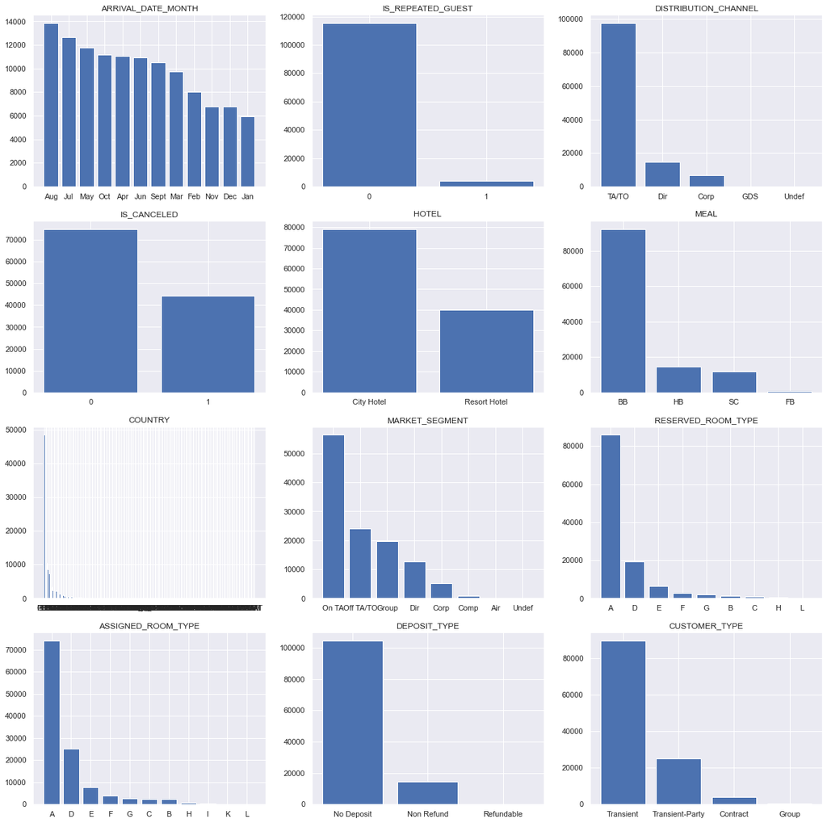

```python
month_abv = {'January': 'Jan', 'February': 'Feb', 'March': 'Mar', 'April': 'Apr', 'June': 'Jun', 'July': 'Jul', 'August': 'Aug', 'September': 'Sept', 'October': 'Oct', 'November': 'Nov', 'December': 'Dec'}
data = data.replace(month_abv)

market_seg = {'Aviation': 'Air', 'Corporate': 'Corp', 'Direct': 'Dir', 'Undefined': 'Undef', 'Groups': 'Group', 'Offline TA/TO': 'Off TA/TO', 'Online TA': 'On TA', 'Complementary': 'Comp'}
data = data.replace(market_seg)

sns.set(style = 'darkgrid')
fig, ax = plt.subplots(figsize=(16, 16))
ax.axis('off')
fig.tight_layout()
for idx, i in enumerate(cats):
    labels = list(data[i].value_counts().index)
    values = list(data[i].value_counts())
    fig.add_subplot(4,3,idx+1)
    plt.bar(labels, values)
    plt.xticks(labels)
    plt.title(i.upper())
```

From the above bar plots of the categorical variables, we can see that the three summer months of August, July, and May had the highest number of hotel bookings. We can see that most guests only had a breakfast (BB) meal type booked. The TA/TO distribution channel and market segment appears to be the most prevalent. Moreover, the most popular room type reserved (and assigned) was room A. Most guests did not provide a desposit and were labeled as transient (as opposed to contract or group) customer types. Furthermore, the classes of the target variable is_cancelled (to be used in the following classification modeling) do not appear to be too unbalanced.

**Look at the top ten countries hotel guests came from:**

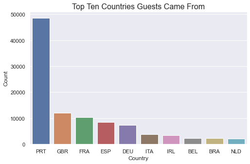

```python
country = data.country.value_counts()

countries = pd.DataFrame({'country':country.index, 'count':country.values})
countries = countries.head(10)

plt.figure(figsize = (8,5))
sns.barplot(x = 'country', y = 'count', data = countries)
plt.ylabel('Count')
plt.xlabel('Country')
plt.title('Top Ten Countries Guests Came From', fontsize = 16)
plt.show()
```

The vast majority of hotel guests came from Portugal. This intuitively makes sense, as both of the hotels in this data set are located in Portugal. A large number of guests also came from Great Britain, France, Spain, and Germany (other European countries).

**Look at the percentage of cancellations per month for each hotel type (city & resort) :**

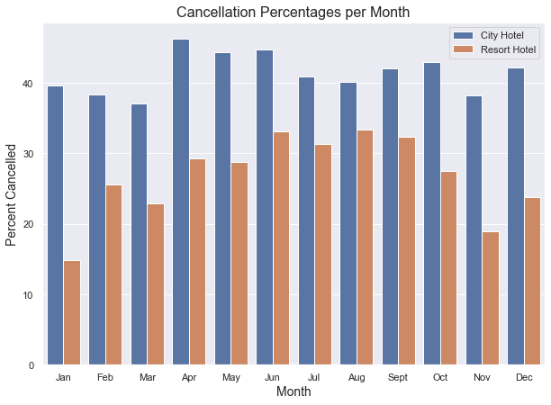

```python
# resort hotel bookings and cancellations:
res_booked = data[(data['hotel'] == 'Resort Hotel')].groupby('arrival_date_month')['hotel'].count()
res_cancelled = data[(data['hotel'] == 'Resort Hotel')].groupby('arrival_date_month')['is_canceled'].sum()

res_cancelled_data = pd.DataFrame({'Hotel': 'Resort Hotel',
                                'Month': list(res_booked.index),
                                'Bookings': list(res_booked.values),
                                'Cancellations': list(res_cancelled.values)})

# city hotel bookings and cancellations:
city_booked = data[(data['hotel'] == 'City Hotel')].groupby('arrival_date_month')['hotel'].count()
city_cancelled = data[(data['hotel'] == 'City Hotel')].groupby('arrival_date_month')['is_canceled'].sum()

city_cancelled_data = pd.DataFrame({'Hotel': 'City Hotel',
                                'Month': list(city_booked.index),
                                'Bookings': list(city_booked.values),
                                'Cancellations': list(city_cancelled.values)})

# cancellation percentages:
full_cancelled_data = pd.concat([res_cancelled_data, city_cancelled_data], ignore_index=True)
full_cancelled_data['cancel_percent'] = full_cancelled_data['Cancellations'] / full_cancelled_data['Bookings'] * 100

# ordered months:
months_ordered = ['Jan', 'Feb', 'Mar', 'Apr', 'May', 'Jun',
          'Jul', 'Aug', 'Sept', 'Oct', 'Nov', 'Dec']
full_cancelled_data['Month'] = pd.Categorical(full_cancelled_data['Month'], categories=months_ordered, ordered=True)

# plot:
plt.figure(figsize=(10, 7))
sns.barplot(x = 'Month', y = 'cancel_percent', hue = 'Hotel',
            hue_order = ['City Hotel', 'Resort Hotel'], data = full_cancelled_data)
plt.title('Cancellation Percentages per Month', fontsize=16)
plt.xlabel('Month', fontsize=14)
plt.ylabel('Percent Cancelled', fontsize=14)
plt.legend(loc= 'upper right')
plt.show()
```

The percentage of hotel bookings cancelled per month appears to be consistently higher for city hotels than resort hotels across all months.

### Convert categorical variables to numeric values, normalize data, & split into training/test sets:

**Convert categorical variables to numeric values:**

```python
hotel_num = {'Resort Hotel': 0, 'City Hotel': 1}
data = data.replace(hotel_num)

month_num = {'Jan': 1, 'Feb': 2, 'Mar': 3, 'Apr': 4, 'May': 5, 'Jun': 6, 'Jul': 7, 'Aug': 8, 'Sept': 9, 'Oct': 10, 'Nov': 11, 'Dec': 12}
data = data.replace(month_num)

meal_num = {'BB': 0, 'FB': 1, 'HB': 2, 'SC': 3}
data = data.replace(meal_num)

market_num = {'Air': 0, 'Corp': 1, 'Dir': 2, 'Undef': 3, 'Group': 4, 'GDS': 4, 'TA/TO': 5, 'Off TA/TO': 5, 'On TA': 6, 'Comp': 7}
data = data.replace(market_num)

room_num = {'A': 0, 'B': 1, 'C': 2, 'D': 3, 'E': 4, 'F': 5, 'G': 6, 'H': 7, 'I': 9, 'K': 10, 'L': 8}
data = data.replace(room_num)

deposit_num = {'No Deposit': 0, 'Non Refund': 1, 'Refundable': 2}
data = data.replace(deposit_num)

customer_num = {'Contract': 0, 'Group': 1, 'Transient': 2, 'Transient-Party': 3}
data = data.replace(customer_num)

reservation_num = {'Canceled': 0, 'Check-Out': 1, 'No-Show': 2}
data = data.replace(reservation_num)

country_oe = OrdinalEncoder()
data['country'] = country_oe.fit_transform(np.array(data['country']).reshape(-1,1))
```

**Normalize data:**

```python
min_max_scaler = preprocessing.MinMaxScaler().fit(data)
data_norm = min_max_scaler.transform(data) # min-max normalization to scale all variables between 0 & 1
data_norm = pd.DataFrame(data_norm)
```

**Isolate target variable (is_cancelled) and split data into training/test sets:**

```python
# set up target variable and data matrix
target = data_norm[1]
matrix = data_norm.drop(data_norm.columns[1], axis=1)
```

```python
# split the data into training and testing groups
x_train, x_test, y_train, y_test = train_test_split(matrix, target, test_size=0.2, random_state=33)
```

### Perform Classification Modeling:

**MULTINOMIAL NAIVE BAYES:**

**Perform classification using multinomial naive bayes and a grid search to optimize the parameters:**

```python
nb = MultinomialNB()
alphas = [0.0001, 0.001, 0.005, 0.01, 0.05, 0.1, 0.2, 0.3, 0.4]
parameters = {'alpha': alphas, 'fit_prior' : [True, False]}      # grid search parameters
gs = GridSearchCV(nb, parameters, verbose=1, cv=5)
```

```python
gs.fit(x_train, y_train)     # perform grid search on training data
```

```
Fitting 5 folds for each of 18 candidates, totalling 90 fits
```

```
[Parallel(n_jobs=1)]: Using backend SequentialBackend with 1 concurrent workers.
[Parallel(n_jobs=1)]: Done  90 out of  90 | elapsed:    3.1s finished
```

```
GridSearchCV(cv=5, estimator=MultinomialNB(),
             param_grid={'alpha': [0.0001, 0.001, 0.005, 0.01, 0.05, 0.1, 0.2,
                                   0.3, 0.4],
                         'fit_prior': [True, False]},
             verbose=1)
```

```python
for (i, j) in gs.best_params_.items():
    print ("The optimal value of", i, "is:", j)
print()
print("The best cross-validation accuracy on the training data was: {}".format(gs.best_score_))
```

```
The optimal value of alpha is: 0.0001
The optimal value of fit_prior is: True

The best cross-validation accuracy on the training data was: 0.7503460067424925
```

**Using the optimal parameters (alpha = .0001 and fit_prior = True), apply model to set aside test data:**

```python
nb = MultinomialNB(alpha=.0001, fit_prior=True)  # initialize classifier with smoothing parameter alpha = .0001  & allow it to learn prior class probabilities

nb.fit(x_train, y_train)                        # fit on training data

pred_test_target = nb.predict(x_test)           # predict classes of test set

print(classification_report(y_test, pred_test_target))  # print classification report
```

```
              precision    recall  f1-score   support

         0.0       0.72      0.99      0.83     15070
         1.0       0.97      0.33      0.49      8772

    accuracy                           0.75     23842
   macro avg       0.85      0.66      0.66     23842
weighted avg       0.81      0.75      0.71     23842
```

Although this multinomial naive bayes classifier is only correctly predicting whether a hotel booking was cancelled 75% of the time, it has a relatively high precision (97%) with respect to the cancelled class. That is, it is not incorrectly predicting that a hotel reservation was cancelled very often. This is important because in order for the hospitality industry to presumably make use of classification models such as this, it would be beneficial to err on the side of caution when attempting to determine whether hotel bookings will ultimately be cancelled (to prevent overbooking).

**Visualize results with confusion matrix:**

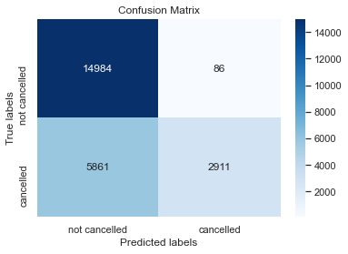

```python
nbcm = confusion_matrix(y_test, pred_test_target)

ax= plt.subplot()
sns.heatmap(nbcm, annot=True, fmt='d', cmap='Blues', ax = ax);

ax.set_xlabel('Predicted labels');ax.set_ylabel('True labels');
ax.set_title('Confusion Matrix');
ax.xaxis.set_ticklabels(['not cancelled', 'cancelled']); ax.yaxis.set_ticklabels(['not cancelled', 'cancelled']);
```

**K-NEAREST NEIGHBORS:**

**Perform classification using k-nearest neighbors and utilizing a grid search to optimize the value of k:**

```python
knn = neighbors.KNeighborsClassifier()
parameters = {'n_neighbors': [1,3,5,7,9]}          # parameters for grid search (values of k=1, k=3, k=5, k=7, k=9)
gs = GridSearchCV(knn, parameters, verbose=1, cv=5)
```

```python
gs.fit(x_train, y_train)     # perform grid search on training data
```

```
Fitting 5 folds for each of 5 candidates, totalling 25 fits
```

```
[Parallel(n_jobs=1)]: Using backend SequentialBackend with 1 concurrent workers.
[Parallel(n_jobs=1)]: Done  25 out of  25 | elapsed:  5.2min finished
```

```
GridSearchCV(cv=5, estimator=KNeighborsClassifier(),
             param_grid={'n_neighbors': [1, 3, 5, 7, 9]}, verbose=1)
```

```python
for (i, j) in gs.best_params_.items():
    print ("The optimal value of", i, "is:", j)
print()
print("The best cross-validation accuracy on the training data was: {}".format(gs.best_score_))
```

```
The optimal value of n_neighbors is: 5

The best cross-validation accuracy on the training data was: 0.8243645275825043
```

**Using the best value of k (k=5), apply model to the set aside test data:**

```python
knn = neighbors.KNeighborsClassifier(n_neighbors=5)      # initialize with k=5

knn.fit(x_train, y_train)                                # fit on training data

pred_test_target = knn.predict(x_test)                   # predict classes of test set

print(classification_report(y_test, pred_test_target))    # print classification report
```

```
              precision    recall  f1-score   support

         0.0       0.86      0.87      0.87     15070
         1.0       0.77      0.76      0.77      8772

    accuracy                           0.83     23842
   macro avg       0.82      0.82      0.82     23842
weighted avg       0.83      0.83      0.83     23842
```

This knn classifier is correctly predicting whether a hotel booking was cancelled 83% of the time. This is an improvement from the prior multinomial naive bayes classifier in terms of overall accuracy. However, the precision (77%) with respect to the cancelled class is worse. This model misclassified more reservations as cancelled that were actually not cancelled.

**Visualize results with confusion matrix:**

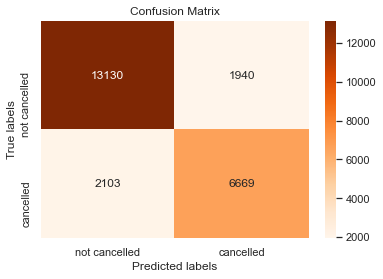

```python
knncm = confusion_matrix(y_test, pred_test_target)

ax= plt.subplot()
sns.heatmap(knncm, annot=True, fmt='d', cmap='Oranges', ax = ax);

ax.set_xlabel('Predicted labels');ax.set_ylabel('True labels');
ax.set_title('Confusion Matrix');
ax.xaxis.set_ticklabels(['not cancelled', 'cancelled']); ax.yaxis.set_ticklabels(['not cancelled', 'cancelled']);
```

**SUPPORT VECTOR MACHINE:**

**Perform classification using support vector classifier and a grid search to optimize the gamma, C, and kernel parameters:**

```python
svm = SVC(class_weight='balanced')                    # initialize svm classifier w/ balanced class weights

parameters = {'gamma': ['scale', 'auto'], 'C': [175, 200, 250, 300, 325], 'kernel': ['rbf', 'poly']}  # grid search parameters

gs = GridSearchCV(svm, parameters, verbose=1, cv=3)   # initialize grid search w/ 3-fold cross-validation
```

**Take random sample of 25% of the data to perform a grid search on (to speed up grid search process):**

```python
sample = data_norm.sample(frac =.25, random_state=35)    # random sample
target_sample = sample[1]                                # target variable
matrix_sample = sample.drop(sample.columns[1], axis=1)   # rest of sample data for grid search
```

**Grid search on sample data:**

```python
gs.fit(matrix_sample, target_sample)                   # perform grid search on sample
```

```
Fitting 3 folds for each of 20 candidates, totalling 60 fits
```

```
[Parallel(n_jobs=1)]: Using backend SequentialBackend with 1 concurrent workers.
[Parallel(n_jobs=1)]: Done  60 out of  60 | elapsed: 46.3min finished
```

```
GridSearchCV(cv=3, estimator=SVC(class_weight='balanced'),
             param_grid={'C': [175, 200, 250, 300, 325],
                         'gamma': ['scale', 'auto'],
                         'kernel': ['rbf', 'poly']},
             verbose=1)
```

```python
for (i, j) in gs.best_params_.items():
    print ("The optimal value of", i, "is:", j)
print()
print("The best cross-validation accuracy on the sample data was: {}".format(gs.best_score_))
```

```
The optimal value of C is: 250
The optimal value of gamma is: scale
The optimal value of kernel is: rbf

The best cross-validation accuracy on the sample data was: 0.8301791826051943
```

**Using the optimal gamma, C, and kernel parameters found using a grid search on the sample data, apply model to the set aside test data:**

```python
svm = SVC(gamma='scale', C=250, kernel='rbf', class_weight='balanced')  # initialize svm classifier with optimal parameters

svm.fit(x_train, y_train)                    # fit on training data

pred_test_target = svm.predict(x_test)           # predict classes of test set

print(classification_report(y_test, pred_test_target))  # print classification report
```

```
              precision    recall  f1-score   support

         0.0       0.90      0.85      0.87     15070
         1.0       0.77      0.84      0.80      8772

    accuracy                           0.85     23842
   macro avg       0.83      0.84      0.84     23842
weighted avg       0.85      0.85      0.85     23842
```

This svm classifier is accurately predicting whether a hotel booking was cancelled 85% of the time. This is slightly better than the prior knn classifier in terms of overall accuracy. However, the precision (77%) with respect to the cancelled class is the same as the knn classifier, and again not as good as the multinomial naive bayes classifier.

**Visualize results with confusion matrix:**

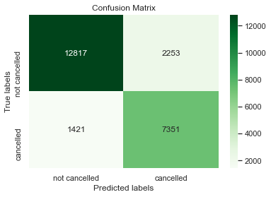

```python
svmcm = confusion_matrix(y_test, pred_test_target)

ax= plt.subplot()
sns.heatmap(svmcm, annot=True, fmt='d', cmap='Greens', ax = ax);

ax.set_xlabel('Predicted labels');ax.set_ylabel('True labels');
ax.set_title('Confusion Matrix');
ax.xaxis.set_ticklabels(['not cancelled', 'cancelled']); ax.yaxis.set_ticklabels(['not cancelled', 'cancelled']);
```

**RANDOM FOREST:**

**Perform classification using random forest decision tree classifier and a grid search to optimize the number of trees, impurity measure, & minimum samples per split:**

```python
rf = ensemble.RandomForestClassifier()
parameters = {'n_estimators': [20,40,50,70,100], 'criterion': ['gini', 'entropy'], 'min_samples_split': [2,4,8,15,30,50,75,100]} # grid search parameters
gs = GridSearchCV(rf, parameters, verbose=1, cv=5)
```

```python
gs.fit(x_train, y_train)     # perform grid search on training data
```

[output not shown]

[output not shown]

[output not shown]

```python
for (i, j) in gs.best_params_.items():
    print ("The optimal value of", i, "is:", j)
print()
print("The best cross-validation accuracy on the training data was: {}".format(gs.best_score_))
```

```
The optimal value of criterion is: gini
The optimal value of min_samples_split is: 2
The optimal value of n_estimators is: 100

The best cross-validation accuracy on the training data was: 0.8912527889553512
```

**Using the optimal parameters (criterion = gini, min_samples_split = 2, n_estimators = 100), apply model to set aside test data:**

```python
rf = ensemble.RandomForestClassifier(criterion='gini', min_samples_split=2, n_estimators=100)  # initialize rf classifier with optimal parameters

rf.fit(x_train, y_train)                    # fit on training data

pred_test_target = rf.predict(x_test)           # predict classes of test set

print(classification_report(y_test, pred_test_target))  # print classification report
```

```
              precision    recall  f1-score   support

         0.0       0.90      0.94      0.92     15070
         1.0       0.89      0.83      0.86      8772

    accuracy                           0.90     23842
   macro avg       0.90      0.88      0.89     23842
weighted avg       0.90      0.90      0.90     23842
```

This random forest classifier is accurately predicting whether a hotel booking was cancelled 90% of the time. This is a relatively high overall accuracy, which is better than the three prior models. The precision (89%) with respect to the cancelled class is better than the knn and svm classifiers, but still not as good as the first multinomial naive bayes classifier. The hospitality industry might want to adopt a model such as this over the first multinomial naive bayes classifier as part of their marketing strategy if pursuing a more aggressive approach. However, doing so would likely increase the risk of potential overbookings.

**Visualize results with confusion matrix:**

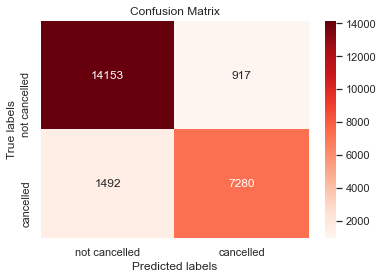

```python
rfcm = confusion_matrix(y_test, pred_test_target)

ax= plt.subplot()
sns.heatmap(rfcm, annot=True, fmt='d', cmap='Reds', ax = ax);

ax.set_xlabel('Predicted labels');ax.set_ylabel('True labels');
ax.set_title('Confusion Matrix');
ax.xaxis.set_ticklabels(['not cancelled', 'cancelled']); ax.yaxis.set_ticklabels(['not cancelled', 'cancelled']);
```

### Compare all four models using ROC curves:

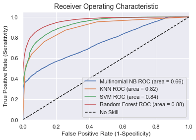

```python
models = [
{
    'label': 'Multinomial NB',
    'model': MultinomialNB(alpha=.0001, fit_prior=True),
},
{
    'label': 'KNN',
    'model': neighbors.KNeighborsClassifier(n_neighbors=5),
},
{
    'label': 'SVM',
    'model': SVC(gamma='scale', C=250, kernel='rbf', class_weight='balanced', probability=True),
},
{
    'label': 'Random Forest',
    'model': ensemble.RandomForestClassifier(criterion='gini', min_samples_split=2, n_estimators=100),
}
]
# iterate through models list:
for m in models:
    model = m['model']              # select the model
    model.fit(x_train, y_train)  # train the model
    y_pred = model.predict(x_test)      # predict the test data
# compute false postive rate, and true positive rate:
    fpr, tpr, thresholds = metrics.roc_curve(y_test, model.predict_proba(x_test)[:,1])
# calculate AUC to display on the plot:
    auc = metrics.roc_auc_score(y_test, model.predict(x_test))
# plot the computed values:
    plt.plot(fpr, tpr, label='%s ROC (area = %0.2f)' % (m['label'], auc))
# settings for the plot:
plt.plot([0, 1], [0, 1],'k--',label='No Skill')
plt.xlim([0.0, 1.0])
plt.ylim([0.0, 1.05])
plt.xlabel('False Positive Rate (1-Specificity)')
plt.ylabel('True Positive Rate (Sensitivity)')
plt.title('Receiver Operating Characteristic', fontsize=14)
plt.legend(loc='lower right')  # legend location
plt.show()                     # display
```

The above graph shows the performance for each of the four models (Multinomial Naive Bayes, KNN, SVM, & Random Forest) over a range of probability thresholds. The random forest classifier performed very well, with highest respective AUC (area under the curve). And although the multinomial naive bayes classifier has a relatively low AUC, as mentioned earlier this classifier displayed the highest precision with respect to the cancelled class.